# Analysis

Aazar and Nadia

2024-05-01

```
##
## Healthy Weight        Obesity     Overweight    Underweight
##          22219          23536          45751           8494
```

# What is in this dataset ?

```r
#Neatly presents table
head(diabetes,10) %>%
  kbl() %>%
  kable_paper() %>%
  scroll_box(height = "300px")
```

| gender | age | hypertension | heart_disease | smoking_history | bmi | HbA1c_level | blood_glucose_level | diabetes | weight_status |
| --- | --- | --- | --- | --- | --- | --- | --- | --- | --- |
| Female | 80 | 0 | 1 | never | 25.19 | 6.6 | 140 | 0 | Overweight |
| Female | 54 | 0 | 0 | No Info | 27.32 | 6.6 | 80 | 0 | Overweight |
| Male | 28 | 0 | 0 | never | 27.32 | 5.7 | 158 | 0 | Overweight |
| Female | 36 | 0 | 0 | current | 23.45 | 5.0 | 155 | 0 | Healthy Weight |
| Male | 76 | 1 | 1 | current | 20.14 | 4.8 | 155 | 0 | Healthy Weight |
| Female | 20 | 0 | 0 | never | 27.32 | 6.6 | 85 | 0 | Overweight |
| Female | 44 | 0 | 0 | never | 19.31 | 6.5 | 200 | 1 | Healthy Weight |
| Female | 79 | 0 | 0 | No Info | 23.86 | 5.7 | 85 | 0 | Healthy Weight |
| Male | 42 | 0 | 0 | never | 33.64 | 4.8 | 145 | 0 | Obesity |
| Female | 32 | 0 | 0 | never | 27.32 | 5.0 | 100 | 0 | Overweight |

# Beta Binomial Model (lecture 7)

```r
library(ggplot2)
# Counting the number of patients with hypertension and diabetes
data_summary <- table(diabetes$hypertension, diabetes$diabetes)
n = sum(data_summary["1", ])  # Total patients with hypertension
x = data_summary["1", "1"]    # Patients with hypertension and diabetes

theta =seq(0,1,0.0001)
alpha_prior = 3
beta_prior = 1
prior = dbeta(theta, alpha_prior, beta_prior)
likelihood = dbinom(x, n, theta)
# posterior
alpha_post = alpha_prior + x
beta_post = beta_prior + n
#posterior = dbeta(theta, alpha_post, beta_post)
# posterior credible interval
qbeta(c(0.025, 0.975), alpha_post, beta_post)
```

```
## [1] 0.2101182 0.2266644
```

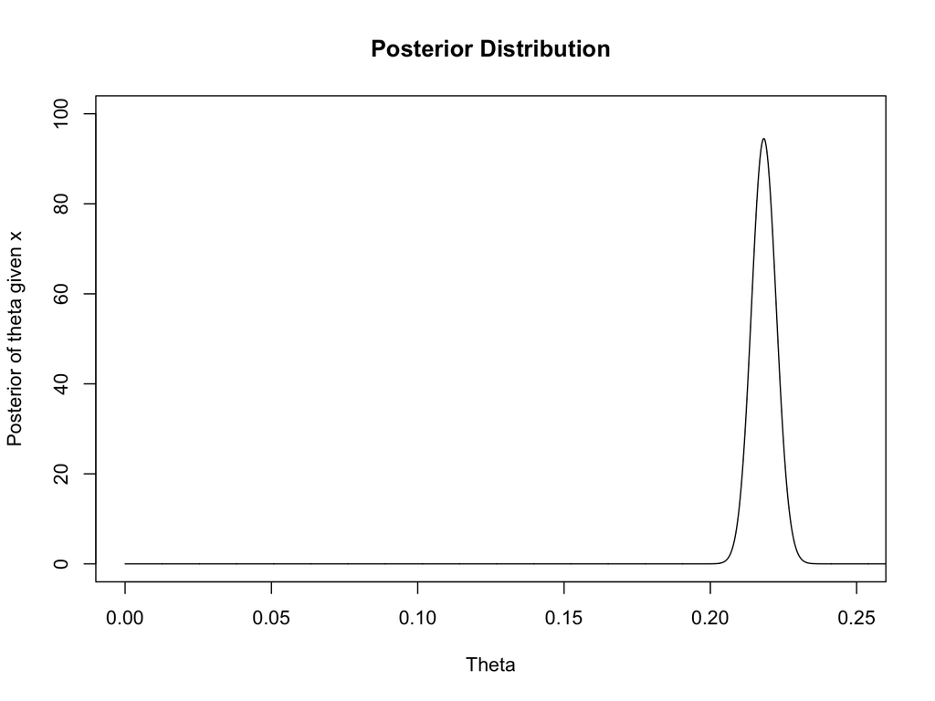

```r
# Plot posterior distribution for each category
plot(NULL, NULL, xlim=c(0, 0.25), ylim=c(0, 100), xlab="Theta", ylab="Posterior of theta given x", main="Posterior Distribution", type="n")

lines(theta, dbeta(theta, shape1=alpha_post, shape2=beta_post))
```

```r
paste("The sample proportion is: ", x/n)
```

```
## [1] "The sample proportion is:  0.278957915831663"
```

# Diabetic Gluclose Levels

We’re reasonably confident that the average glucose level lies in the range of 170 to 190 mg/dL. Our prior probability that the average glucose level is between 170 mg/dL and 190 mg/dL is about 68%. Our prior probability that the average glucose level is between 160 mg/dL and 200 mg/dL is about 95%.

```r
library(rjags)
library(coda)

set.seed(3153)
tau0 = 10
mu0 = 180

diabetic <- diabetes %>%
  filter(diabetes == 1)
sigma
```

```
## function (object, ...)
## UseMethod("sigma")
## <bytecode: 0x1082b42b0>
## <environment: namespace:stats>
```

```r
#data
n= nrow(diabetic)
sigma= sd(diabetic$blood_glucose_level)
xbar= mean(diabetic$blood_glucose_level)

x = diabetic$blood_glucose_level
#posterior SD
tau_n = 1 / sqrt(n / sigma ^ 2 + 1 / tau0 ^ 2)
#  0.6347694
tau_n
```

```
## [1] 0.6347694
```

```r
tau_n
```

```
## [1] 0.6347694
```

```r
#posterior mean
mu_n = mu0 * (1 / tau0 ^ 2) / (1 / tau_n ^ 2) + xbar * (n / sigma ^ 2) / (1 / tau_n ^ 2)
theta = seq(mu0 - 3 * tau0, mu0 + 3 * tau0, 0.01) # the grid is just for plotting
# 194.0379
mu_n
```

```
## [1] 194.0379
```

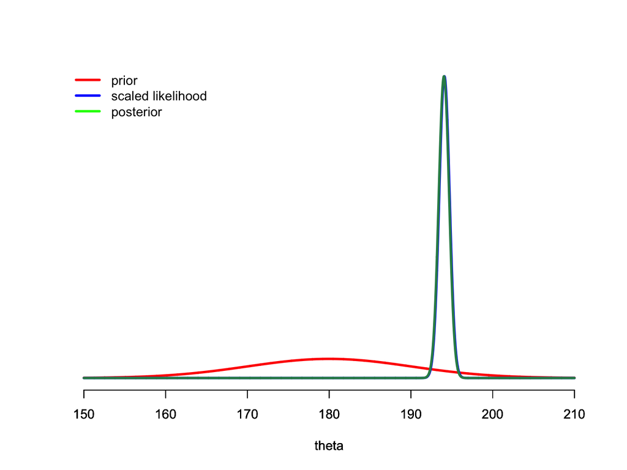

```r
# prior
prior = dnorm(theta, mu0, tau0)
# likelihood
likelihood = dnorm(xbar, theta, sigma / sqrt(n))
# posterior
posterior = dnorm(theta, mu_n, tau_n)
# plot
ymax = max(c(prior, posterior))
scaled_likelihood = likelihood * ymax / max(likelihood)

plot(theta, prior, type='l', col='red', xlim= range(theta), ylim=c(0, ymax), ylab='', yaxt='n',lwd=3, frame.plot = FALSE)
par(new=T)
plot(theta, scaled_likelihood, type='l', col='blue', xlim=range(theta), ylim=c(0, ymax), ylab='',  yaxt='n',lwd=3, frame.plot = FALSE)
par(new=T)
plot(theta, posterior, type='l', col='seagreen', xlim=range(theta), ylim=c(0, ymax), ylab='', yaxt='n',lwd=3, frame.plot = FALSE)
legend("topleft", c("prior", "scaled likelihood", "posterior"), lty=1, col=c("red", " blue", "green"),lwd=3,  bty = "n")
```

# There is a 95% posterior probability that the true mean glucose level for the diabetic population falls between 192.794 mg/dL and 195.282 mg/dL.

```r
qnorm(c(0.025,0.975), 194.0379,  0.6347694) # Postereior Mean
```

```
## [1] 192.7938 195.2820
```

```r
library(rjags)
Nrep = 10000
Nchains = 3

# data
# data has already been loaded in previous code

# model
model_string <- "model{

  # Likelihood
  for (i in 1:n){
    x[i] ~ dnorm(theta, 1 / sigma ^ 2)
  }
  sigma <-   58.64111

  #OR simply dnorm(theta, n / sigma ^ 2)


  # Prior
  theta ~ dnorm(mu0, 1 / tau0 ^ 2)
  mu0 <- 180
  tau0 <- 10

}"

# Compile the model
dataList = list(x=x, n=n)

model <- jags.model(textConnection(model_string),
                    data=dataList,
                    n.chains=Nchains)
## --------------------------------
update(model, 1000, progress.bar="none")

posterior_sample <- coda.samples(model,
                                 variable.names=c("theta"),
                                 n.iter=Nrep,
                                 progress.bar="none")
# Summarize and check diagnostics
summary(posterior_sample)
```

```
##
## Iterations = 1001:11000
## Thinning interval = 1
## Number of chains = 3
## Sample size per chain = 10000
##
## 1. Empirical mean and standard deviation for each variable,
##    plus standard error of the mean:
##
##           Mean             SD       Naive SE Time-series SE
##      1.940e+02      6.339e-01      3.660e-03      3.659e-03
##
## 2. Quantiles for each variable:
##
##  2.5%   25%   50%   75% 97.5%
## 192.8 193.6 194.0 194.5 195.3
```

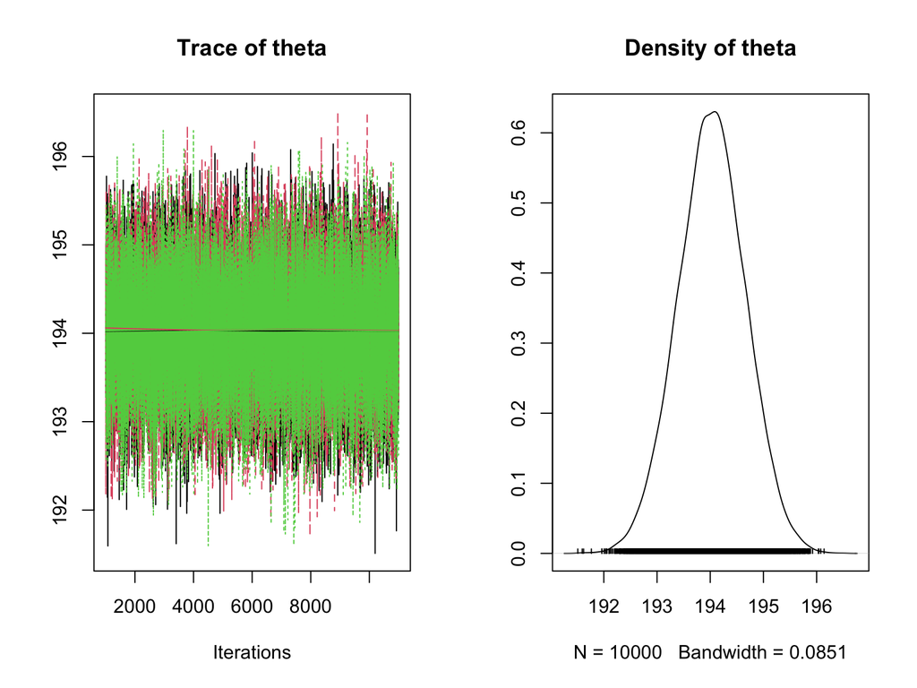

```r
## --------------------------------
plot(posterior_sample)
```

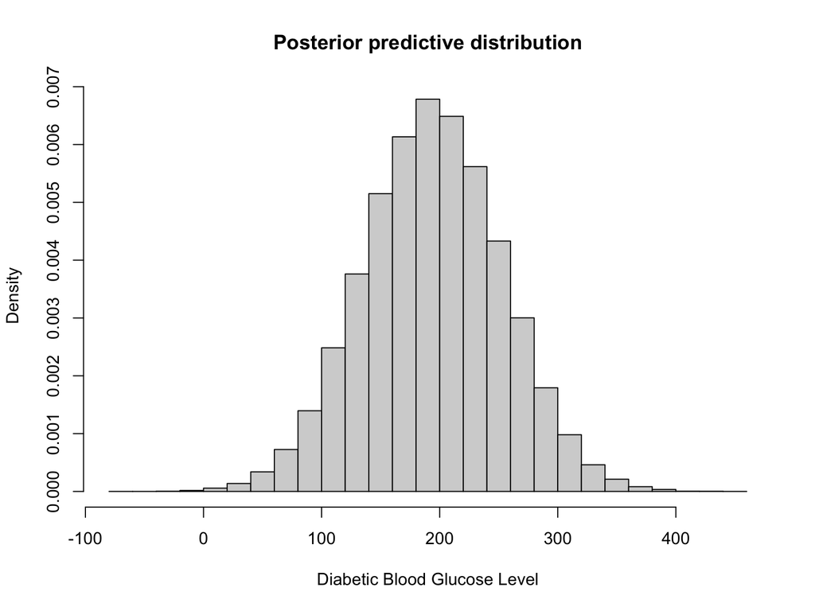

```r
## ---- fig.height=3---------------
theta_sim = rnorm(100000, mu_n, tau_n)
x_sim = rnorm(100000, theta_sim, sigma)
hist(x_sim, freq = FALSE, breaks = 30,
 xlab = "Diabetic Blood Glucose Level",
 main = "Posterior predictive distribution")
```

```r
## --------------------------------
quantile(x_sim, c(0.025, 0.975))
```

```
##      2.5%     97.5%
##  79.36896 309.08959
```

```r
#    2.5%    97.5%
# 79.1999 308.1716

## --------------------------------
(sum(x < quantile(x_sim, 0.025)) + sum(x > quantile(x_sim, 0.975))) / n
```

```
## [1] 0
```